# Querying MIMIC-III – Tutorial Problem – SQL

efg | 2018-09-21 | Updated 2018-12-31.

# Overview

The purpose of this RStudio notebook is to reproduce the SQL “Tutorial Problem” from [Querying MIMIC-III](https://mimic.physionet.org/tutorials/intro-to-mimic-iii/), Section 8. Unfortuantely, the online source shows SQL code but does not show the “correct” answers, so a definitive conclusion that this all matches is not possible.

The examples from Section 3 “Patient numbers” through Section 7 “Services are in a separate notebook.

**An equivalent Tidyverse example shows roughly the same steps using RStudio notebooks and dplyr/dbplyr for data manipulation instead of SQL.** This enables a direct comparison between solving the problem using SQL and dplyr/dbplyr.

Many of the comments below are from the source above.

SQL statements were lightly edited for readability in the SQL program “chunks”. The output of each SQL statement was directed to the variable `output.var` in the SQL chunk definition to document the dimensions of the returned results. `output.var` results could be displayed or manipulated in any way.

Units were added to some of the variable names for clarity.

Prerequisites: This tutorial assumes that you have an active connection to an instance of MIMIC-III running on PostgreSQL. Note also that all the queries are written assuming that the MIMIC-III database is on your default search path.

NOTES:

Either RPostgreSQL or RPostgres seems to work with Postgres SQL queries. However, only RPostgres works with Step 7 with the dplyr solution, so a switch in database drivers is made in step 7 for consistency with the dplyr solution.

# Setup

Packages

```r
library(DBI)
library(RPostgreSQL)
library(RPostgres)
library(tidyverse)
library(kableExtra)
```

Helper function: Common formatting mostly for data.frames/tibbles below

```r
Show <- function(data, caption = NULL)
{
  data                               %>%
  kable("html", caption = caption)   %>%
  kable_styling(bootstrap_options = c("striped", "bordered", "condensed"),
                position = "left", full_width = FALSE, font_size=12)
}
```

Open database

```r
MimicDB <- dbConnect(RPostgreSQL::PostgreSQL(),    # PostgreSQL for Steps 1 - 6
                     dbname   = "mimic",
                     user     = Sys.getenv("MIMIC_User"),
                     password = Sys.getenv("MIMIC_Password"),
                     options  = "-c search_path=mimiciii")

MimicVersion <- "MIMIC-III, v1.4"
```

# Querying MIMIC-III

Note: All SQL chunks below put results in object SQLresults for processing in R.

## 8. Tutorial problem

How would you gather useful information about patients admitted to the ICU? The problem can be broken down into several parts:

### Step 1

First start with retrieving `subject_id`, `hadm_id`, `icustay_id`, `intime`, and `outtime` from the `icustays` table.

```sql
SELECT
  ie.subject_id,
  ie.hadm_id,
  ie.icustay_id,
  ie.intime,
  ie.outtime
FROM
  icustays ie
```

```r
dim(SQLresults)
```

```
[1] 61532     5
```

```r
SQLresults %>% head() %>% Show(caption = "Selected fields from icustays")
```

Selected fields from icustays

| subject_id | hadm_id | icustay_id | intime | outtime |
| --- | --- | --- | --- | --- |
| 268 | 110404 | 280836 | 2198-02-14 | 2198-02-18 |
| 269 | 106296 | 206613 | 2170-11-05 | 2170-11-08 |
| 270 | 188028 | 220345 | 2128-06-24 | 2128-06-27 |
| 271 | 173727 | 249196 | 2120-08-07 | 2120-08-10 |
| 272 | 164716 | 210407 | 2186-12-25 | 2186-12-27 |
| 273 | 158689 | 241507 | 2141-04-19 | 2141-04-20 |

### Step 2

Using the patients table retrieve the calculated age of patients.

```sql
SELECT
  ie.subject_id,
  ie.hadm_id,
  ie.icustay_id,
  ie.intime,
  ie.outtime,
  ROUND((cast(ie.intime as date) - cast(pat.dob as date))/365.242, 2) AS age_years
FROM
  icustays ie

  INNER JOIN patients pat
  ON ie.subject_id = pat.subject_id;
```

```r
dim(SQLresults)
```

```
[1] 61532     6
```

```r
SQLresults %>%
  head()   %>%
  Show(caption = "Calculated ages")
```

Calculated ages

| subject_id | hadm_id | icustay_id | intime | outtime | age_years |
| --- | --- | --- | --- | --- | --- |
| 268 | 110404 | 280836 | 2198-02-14 | 2198-02-18 | 65.98 |
| 269 | 106296 | 206613 | 2170-11-05 | 2170-11-08 | 40.10 |
| 270 | 188028 | 220345 | 2128-06-24 | 2128-06-27 | 80.08 |
| 271 | 173727 | 249196 | 2120-08-07 | 2120-08-10 | 45.68 |
| 272 | 164716 | 210407 | 2186-12-25 | 2186-12-27 | 67.10 |
| 273 | 158689 | 241507 | 2141-04-19 | 2141-04-20 | 33.69 |

The following graphic is an addition to the original example.

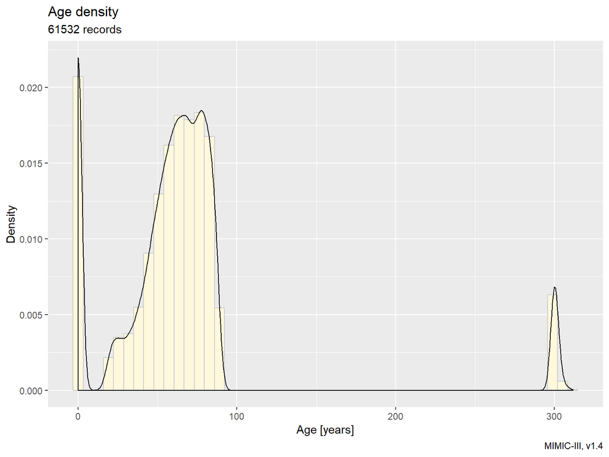

```r
ggplot(SQLresults, aes(x=age_years, y=..density..))          +
  geom_histogram(fill="cornsilk", color="grey80", bins=50)   +
  geom_density()                                             +
  labs(title    = "Age density",
       subtitle = paste0(nrow(SQLresults), " records"),
       x = "Age [years]",
       y = "Density",
       caption = MimicVersion)
```

Note the strange convention for ages > 89 to be represented as ~300 years.

### Step 3

Separate neonates from adult patients.

Unclear here why > 100 used to find ages ~300 years old to represent ages > 89.

```sql
SELECT
  ie.subject_id,
  ie.hadm_id,
  ie.icustay_id,
  ie.intime,
  ie.outtime,

  ROUND((cast(ie.intime as date) - cast(pat.dob as date))/365.242, 2) AS age_years,

  CASE
    WHEN ROUND((cast(ie.intime as date) - cast(pat.dob as date))/365.242, 2) <= 1
    THEN 'neonate'

    WHEN ROUND((cast(ie.intime as date) - cast(pat.dob as date))/365.242, 2) <= 14
    THEN 'middle'

    -- all ages > 89 in the database were replaced with 300
    WHEN ROUND((cast(ie.intime as date) - cast(pat.dob as date))/365.242, 2) > 100
    then '>89'

    ELSE 'adult'
  END AS ICUSTAY_AGE_GROUP

FROM
  icustays ie

  INNER JOIN patients pat
  ON ie.subject_id = pat.subject_id
```

```r
dim(SQLresults)
```

```
[1] 61532     7
```

```r
SQLresults %>%
  head()   %>%
  Show()
```

| subject_id | hadm_id | icustay_id | intime | outtime | age_years | icustay_age_group |
| --- | --- | --- | --- | --- | --- | --- |
| 268 | 110404 | 280836 | 2198-02-14 | 2198-02-18 | 65.98 | adult |
| 269 | 106296 | 206613 | 2170-11-05 | 2170-11-08 | 40.10 | adult |
| 270 | 188028 | 220345 | 2128-06-24 | 2128-06-27 | 80.08 | adult |
| 271 | 173727 | 249196 | 2120-08-07 | 2120-08-10 | 45.68 | adult |
| 272 | 164716 | 210407 | 2186-12-25 | 2186-12-27 | 67.10 | adult |
| 273 | 158689 | 241507 | 2141-04-19 | 2141-04-20 | 33.69 | adult |

```r
SQLresults                    %>%
  group_by(icustay_age_group) %>%
  count()                     %>%
  Show(caption = "Counts by Age Group")
```

Counts by Age Group

| icustay_age_group | n |
| --- | --- |
| >89 | 2721 |
| adult | 50711 |
| neonate | 8100 |

### Step 4

By incorporating the admissions table, find how long each stay was BEFORE the patients were admitted to the ICU.

Changed original query to return preiculos in days instead of years.

```sql
SELECT
  ie.subject_id,
  ie.hadm_id,
  ie.icustay_id,
  ie.intime,
  ie.outtime,

  ROUND((cast(ie.intime as date) - cast(pat.dob as date))      /365.242, 2) as age_years,
        (cast(ie.intime as date) - cast(adm.admittime as date))             as preiculos_days,

  CASE
    WHEN ROUND((cast(ie.intime as date) - cast(pat.dob as date))/365.242, 2) <= 1
    THEN 'neonate'

    WHEN ROUND((cast(ie.intime as date) - cast(pat.dob as date))/365.242, 2) <= 14
    THEN 'middle'

    -- all ages > 89 in the database were replaced with ~300
    WHEN ROUND((cast(ie.intime as date) - cast(pat.dob as date))/365.242, 2) > 100
    THEN '>89'

    ELSE 'adult'
  END AS ICUSTAY_AGE_GROUP

FROM
  icustays ie

  INNER JOIN patients pat
  ON ie.subject_id = pat.subject_id

  INNER JOIN admissions adm
  ON ie.hadm_id = adm.hadm_id
```

```r
dim(SQLresults)
```

```
[1] 61532     8
```

```r
SQLresults %>% head() %>% Show(caption = "Pre-ICU Length of Stay [days]")
```

Pre-ICU Length of Stay [days]

| subject_id | hadm_id | icustay_id | intime | outtime | age_years | preiculos_days | icustay_age_group |
| --- | --- | --- | --- | --- | --- | --- | --- |
| 268 | 110404 | 280836 | 2198-02-14 | 2198-02-18 | 65.98 | 3 | adult |
| 269 | 106296 | 206613 | 2170-11-05 | 2170-11-08 | 40.10 | 0 | adult |
| 270 | 188028 | 220345 | 2128-06-24 | 2128-06-27 | 80.08 | 1 | adult |
| 271 | 173727 | 249196 | 2120-08-07 | 2120-08-10 | 45.68 | 0 | adult |
| 272 | 164716 | 210407 | 2186-12-25 | 2186-12-27 | 67.10 | 0 | adult |
| 273 | 158689 | 241507 | 2141-04-19 | 2141-04-20 | 33.69 | 0 | adult |

```r
counts    <- table(SQLresults$icustay_age_group, useNA = "ifany")
facetName <- paste0(names(counts), " [", counts, "]")

variableLabeller <- function(variable,value)
{
  return(facetName[value])
}
```

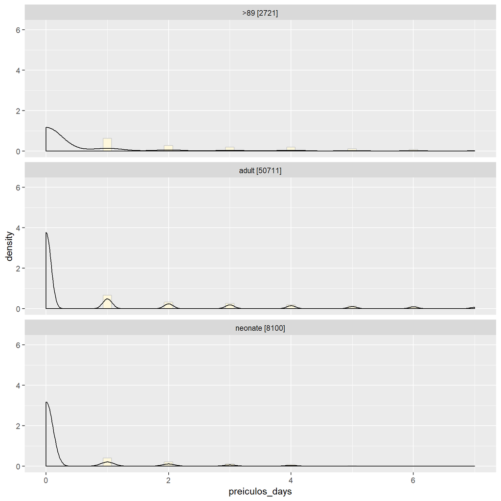

```r
ggplot(SQLresults, aes(x = preiculos_days, y= ..density..))        +
  geom_histogram(fill = "cornsilk", color = "grey80", bins = 50)   +
  geom_density()                                                   +
  xlim(0, 7)                                                       +
  facet_wrap(~icustay_age_group, nrow=length(counts),
             labeller = as_labeller(variableLabeller))
```

### Step 5

Next find the date of the patient’s death if applicable.

```sql
SELECT
  ie.subject_id,
  ie.hadm_id,
  ie.icustay_id,
  ie.intime,
  ie.outtime,
  adm.deathtime,

  ROUND((cast(ie.intime as date) - cast(pat.dob as date))      /365.242, 2) as age_years,
        (cast(ie.intime as date) - cast(adm.admittime as date))             as preiculos_days,

  CASE
    WHEN ROUND((cast(ie.intime as date) - cast(pat.dob as date))/365.242, 2) <= 1
    THEN 'neonate'

    WHEN ROUND((cast(ie.intime as date) - cast(pat.dob as date))/365.242, 2) <= 14
    THEN 'middle'

    -- all ages > 89 in the database were replaced with 300
    WHEN ROUND((cast(ie.intime as date) - cast(pat.dob as date))/365.242, 2) > 100
    THEN '>89'

    ELSE 'adult'
  END AS ICUSTAY_AGE_GROUP

FROM
  icustays ie

  INNER JOIN patients pat
  ON ie.subject_id = pat.subject_id

  INNER JOIN admissions adm
  ON ie.hadm_id = adm.hadm_id
```

```r
dim(SQLresults)
```

```
[1] 61532     9
```

```r
SQLresults %>% head() %>% Show(caption = "Show Death Time (if applicable)")
```

Show Death Time (if applicable)

| subject_id | hadm_id | icustay_id | intime | outtime | deathtime | age_years | preiculos_days | icustay_age_group |
| --- | --- | --- | --- | --- | --- | --- | --- | --- |
| 268 | 110404 | 280836 | 2198-02-14 | 2198-02-18 | 2198-02-18 03:55:00 | 65.98 | 3 | adult |
| 269 | 106296 | 206613 | 2170-11-05 | 2170-11-08 | NA | 40.10 | 0 | adult |
| 270 | 188028 | 220345 | 2128-06-24 | 2128-06-27 | NA | 80.08 | 1 | adult |
| 271 | 173727 | 249196 | 2120-08-07 | 2120-08-10 | NA | 45.68 | 0 | adult |
| 272 | 164716 | 210407 | 2186-12-25 | 2186-12-27 | NA | 67.10 | 0 | adult |
| 273 | 158689 | 241507 | 2141-04-19 | 2141-04-20 | NA | 33.69 | 0 | adult |

```r
deaths <-
  SQLresults                 %>%
  filter(!is.na(deathtime))
```

Counts of deaths

```r
deaths %>% count() %>% Show()
```

| n |
| --- |
| 6609 |

```r
deaths                                              %>%
  group_by(icustay_age_group)                       %>%
  summarize(n = n(),
            minAge    = min(age_years),
            Q25age    = quantile(age_years, 0.25),
            medianAge = median(age_years),
            meanAge   = round(mean(age_years), 2),
            Q75age    = quantile(age_years, 0.75),
            maxAge    = max(age_years))             %>%
  Show(caption = "Stats by age group for patients who died")
```

Stats by age group for patients who died

| icustay_age_group | n | minAge | Q25age | medianAge | meanAge | Q75age | maxAge |
| --- | --- | --- | --- | --- | --- | --- | --- |
| >89 | 590 | 300.00 | 300.00 | 300.0 | 300.42 | 300.0275 | 310.17 |
| adult | 5955 | 15.17 | 58.28 | 70.9 | 68.09 | 80.3300 | 88.99 |
| neonate | 64 | 0.00 | 0.00 | 0.0 | 0.00 | 0.0000 | 0.06 |

### Step 6

Then find those deaths that occurred while the patients were in the hospital.

```sql
SELECT
  ie.subject_id,
  ie.hadm_id,
  ie.icustay_id,
  ie.intime,
  ie.outtime,
  adm.deathtime,

  ROUND((cast(ie.intime as date) - cast(pat.dob as date))      /365.242, 2) as age_years,
        (cast(ie.intime as date) - cast(adm.admittime as date))             as preiculos_days,

  CASE
    WHEN ROUND((cast(ie.intime as date) - cast(pat.dob as date))/365.242, 2) <= 1
    THEN 'neonate'

    WHEN ROUND((cast(ie.intime as date) - cast(pat.dob as date))/365.242, 2) <= 14
    THEN 'middle'

    -- all ages > 89 in the database were replaced with 300
    WHEN ROUND((cast(ie.intime as date) - cast(pat.dob as date))/365.242, 2) > 100
    THEN '>89'
    ELSE 'adult'
  END AS ICUSTAY_AGE_GROUP,

  -- note that there is already a "hospital_expire_flag" field in the admissions table
  CASE
    WHEN adm.hospital_expire_flag = 1
    THEN 'Y'
    ELSE 'N'
  END AS hospital_expire_flag

FROM
  icustays ie

  INNER JOIN patients pat
  ON ie.subject_id = pat.subject_id

  INNER JOIN admissions adm
  ON ie.hadm_id = adm.hadm_id
```

```r
dim(SQLresults)
```

```
[1] 61532    10
```

```r
SQLresults %>% head() %>% Show()
```

| subject_id | hadm_id | icustay_id | intime | outtime | deathtime | age_years | preiculos_days | icustay_age_group | hospital_expire_flag |
| --- | --- | --- | --- | --- | --- | --- | --- | --- | --- |
| 268 | 110404 | 280836 | 2198-02-14 | 2198-02-18 | 2198-02-18 03:55:00 | 65.98 | 3 | adult | Y |
| 269 | 106296 | 206613 | 2170-11-05 | 2170-11-08 | NA | 40.10 | 0 | adult | N |
| 270 | 188028 | 220345 | 2128-06-24 | 2128-06-27 | NA | 80.08 | 1 | adult | N |
| 271 | 173727 | 249196 | 2120-08-07 | 2120-08-10 | NA | 45.68 | 0 | adult | N |
| 272 | 164716 | 210407 | 2186-12-25 | 2186-12-27 | NA | 67.10 | 0 | adult | N |
| 273 | 158689 | 241507 | 2141-04-19 | 2141-04-20 | NA | 33.69 | 0 | adult | N |

```r
SQLresults                                           %>%
  group_by(icustay_age_group, hospital_expire_flag)  %>%
  count()                                            %>%
  spread(hospital_expire_flag, n)                    %>%
  Show(caption = "Counts of Hospital Deaths ('Y')")
```

Counts of Hospital Deaths (‘Y’)

| icustay_age_group | N | Y |
| --- | --- | --- |
| >89 | 2131 | 590 |
| adult | 44756 | 5955 |
| neonate | 8036 | 64 |

### Step 7

```r
dbDisconnect(MimicDB)
```

```
[1] TRUE
```

```r
MimicDB <- dbConnect(RPostgres::Postgres(),    # Postgres for Step 7
                     dbname   = "mimic",
                     user     = Sys.getenv("MIMIC_User"),
                     password = Sys.getenv("MIMIC_Password"),
                     bigint   = "integer",
                     options  = "-c search_path=mimiciii")
```

Find how many of those deaths occurred within the ICU.

```sql
SELECT
  ie.subject_id,
  ie.hadm_id,
  ie.icustay_id,
  ie.intime,
  ie.outtime,
  adm.deathtime,

  ROUND((cast(ie.intime as date) - cast(pat.dob as date))      /365.242, 2) as age_years,
        (cast(ie.intime as date) - cast(adm.admittime as date))             as preiculos_days,

  CASE
    WHEN ROUND((cast(ie.intime as date) - cast(pat.dob as date))/365.242, 2) <= 1
    THEN 'neonate'

    WHEN ROUND((cast(ie.intime as date) - cast(pat.dob as date))/365.242, 2) <= 14
    THEN 'middle'

    -- all ages > 89 in the database were replaced with 300
    WHEN ROUND((cast(ie.intime as date) - cast(pat.dob as date))/365.242, 2) > 100
    THEN '>89'
    ELSE 'adult'
  END AS ICUSTAY_AGE_GROUP,

  -- note that there is already a "hospital_expire_flag" field in the admissions table
  CASE
    WHEN adm.hospital_expire_flag = 1
    THEN 'Y'
    ELSE 'N'
  END AS hospital_expire_flag,

  -- note also that hospital_expire_flag is equivalent to "Is adm.deathtime not null?"
  CASE
    WHEN adm.deathtime BETWEEN ie.intime and ie.outtime
    THEN 'Y'

    -- sometimes there are typographical errors in the death date, so check before intime
    WHEN adm.deathtime <= ie.intime
    THEN 'Y'

    WHEN adm.dischtime          <= ie.outtime     AND
         adm.discharge_location  = 'DEAD/EXPIRED'
    THEN 'Y'
    ELSE 'N'

  END AS ICUSTAY_EXPIRE_FLAG

FROM
  icustays ie

  INNER JOIN patients pat
  ON ie.subject_id = pat.subject_id

  INNER JOIN admissions adm
  ON ie.hadm_id = adm.hadm_id

ORDER BY
  SUBJECT_ID,
  HADM_ID
```

```r
dim(SQLresults)
```

```
[1] 61532    11
```

```r
SQLresults %>% head() %>% Show()
```

| subject_id | hadm_id | icustay_id | intime | outtime | deathtime | age_years | preiculos_days | icustay_age_group | hospital_expire_flag | icustay_expire_flag |
| --- | --- | --- | --- | --- | --- | --- | --- | --- | --- | --- |
| 2 | 163353 | 243653 | 2138-07-17 21:20:07 | 2138-07-17 23:32:21 | NA | 0.00 | 0 | neonate | N | N |
| 3 | 145834 | 211552 | 2101-10-20 19:10:11 | 2101-10-26 20:43:09 | NA | 76.52 | 0 | adult | N | N |
| 4 | 185777 | 294638 | 2191-03-16 00:29:31 | 2191-03-17 16:46:31 | NA | 47.84 | 0 | adult | N | N |
| 5 | 178980 | 214757 | 2103-02-02 06:04:24 | 2103-02-02 08:06:00 | NA | 0.00 | 0 | neonate | N | N |
| 6 | 107064 | 228232 | 2175-05-30 21:30:54 | 2175-06-03 13:39:54 | NA | 65.94 | 0 | adult | N | N |
| 7 | 118037 | 236754 | 2121-05-25 03:26:01 | 2121-05-25 21:10:19 | NA | 0.01 | 2 | neonate | N | N |

```r
table(SQLresults$icustay_expire_flag)
```

```
    N     Y
56911  4621
```

```r
SQLresults                                          %>%
  group_by(icustay_age_group, icustay_expire_flag)  %>%
  count()                                           %>%
  spread(icustay_expire_flag, n)                    %>%
  Show(caption = "Counts of Deaths in ICU ('Y')")
```

Counts of Deaths in ICU (‘Y’)

| icustay_age_group | N | Y |
| --- | --- | --- |
| >89 | 2338 | 383 |
| adult | 46537 | 4174 |
| neonate | 8036 | 64 |

```r
table(SQLresults$hospital_expire_flag, SQLresults$icustay_expire_flag)
```

```
        N     Y
  N 54923     0
  Y  1988  4621
```

# Close database

```r
dbDisconnect(MimicDB)
```

Processing time: 51.3 secs

2018-12-31 2144